# Repeated Measures ANOVA

2025

## Introduction

- One-way ANOVA (Analysis of Variance) is used to determine if there are **any** differences between the means of at least two (but usually three or more) independent groups based on one categorical independent variable.
- A one-way **repeated measures** ANOVA is used to test for differences in the means of two or more groups when observations from that group are obtained from the same subjects.

## Between-subjects versus within-subjects factors

- All the same trade-offs we described for t-tests also apply here.
- Advantage: individual differences possibly reduced as a source of between-group differences.
- Advantage: sample size is not divided between conditions so can require fewer subjects.
- Disadvantage: fewer subjects \(\rightarrow\) smaller degrees of freedom \(\rightarrow\) higher / fatter tails \(\rightarrow\) less power.

## Intuition for repeated measures ANOVA

  \[F = \frac{MS_{between-levels}}{MS_{within-levels}}\]
- One-way repeated measures ANOVA:

  \[F = \frac{MS_{between-levels}}{MS_{within-levels} - MS_{between-subjects}}\]

## Formal treatment

- \(k\) is the number of factor levels
- \(n\) is the number of subjects
- \(x_{ij}\) is observation from factor level \(i\) and subject \(j\)

\[ \begin{align} SS_{between-levels} &= n \sum_{i=1}^k (\bar{x_{i \bullet}} - \bar{x_{\bullet \bullet}})^2 \\ SS_{within-levels} &= \sum_{i=1}^k \sum_{j=1}^n (x_{ij} - \bar{x_{i \bullet}})^2 \\ SS_{between-subject} &= k \sum_{j=1}^n (\bar{x_{\bullet j}} - \bar{x_{\bullet \bullet}})^2 \\ SS_{error} &= SS_{within-levels} - SS_{between-subject} \\ \end{align} \]

- The nomenclature \(SS_{error}\) will make more sense in the coming lectures.

## One-Way ANOVA Table (for independent groups)

| **Source** | **Df** | **SS** | **MS** | **F** | **P(>F)** |
| --- | --- | --- | --- | --- | --- |
| Between groups | \(k-1\) | see above | \(\frac{SS_{between}}{Df_{between}}\) | \(\frac{MS_{between}}{MS_{within}}\) |  |
| Within groups | \(N-k\) | see above | \(\frac{SS_{within}}{Df_{within}}\) |  |  |
| Total | \(N-1\) | see above |  |  |  |

## One-Way Repeated Measures ANOVA Table

| **Source** | **Df** | **SS** | **MS** | **F** | **P(>F)** |
| --- | --- | --- | --- | --- | --- |
| Within-subjects | \(k-1\) | see above | \(\frac{SS_{within}}{Df_{within}}\) | \(\frac{MS_{within}}{MS_{error}}\) |  |
| Error | \((k-1)(n-1)\) | see above | \(\frac{SS_{error}}{Df_{error}}\) |  |  |
| Total | \(nk-1\) | see above |  |  |  |

## Repeated measures ANOVA data

```
##      level subject     score
##     <fctr>  <fctr>     <num>
##  1:      1       1 11.262954
##  2:      1       2  9.673767
##  3:      1       3 11.329799
##  4:      1       4 11.272429
##  5:      1       5 10.414641
##  6:      2       1 18.460050
##  7:      2       2 19.071433
##  8:      2       3 19.705280
##  9:      2       4 19.994233
## 10:      2       5 22.404653
## 11:      3       1 30.763593
## 12:      3       2 29.200991
## 13:      3       3 28.852343
## 14:      3       4 29.710538
## 15:      3       5 29.700785
```

## Repeated measures ANOVA using `ez`

```r
## Use the function `ezANOVA()` from the `ez` package to
## perform a repeated measures ANOVA
d[, subject := factor(subject)]
d[, level := factor(level)]
aov_res <- ezANOVA(
  data=d, ## where the data is located
  dv=score, ## the dependent variable
  wid=subject, ## the repeated measure indicator column
  within = .(level), ## a list of repeated measures factors
  type = 3 ## type of sums of squares desired
)
```

```
## $ANOVA
##   Effect DFn DFd        F            p p<.05      ges
## 2  level   2   8 370.7886 1.297461e-08     * 0.985266
##
## $`Mauchly's Test for Sphericity`
##   Effect         W         p p<.05
## 2  level 0.5279246 0.3835816
##
## $`Sphericity Corrections`
##   Effect      GGe        p[GG] p[GG]<.05       HFe        p[HF] p[HF]<.05
## 2  level 0.679313 2.305263e-06         * 0.9073176 5.770786e-08         *
```

## Reporting the results

We performed a one-way repeated measures ANOVA to examine the effect of the factor “level” on the dependent variable. This analysis revealed a significant main effect of the factor “level” (\(F(2, 8) = 370.79, p < .001, \eta^2 = .985\)). The effect size, as measured by generalized eta-squared, indicated that approximately 98.5% of the variance in the dependent variable could be attributed to the effect of level, suggesting a strong effect.

Mauchly’s test for sphericity was conducted to examine the assumption of sphericity in the repeated measures design. The test was not significant (\(W = 0.528, p = .384\)), indicating that the assumption of sphericity was not violated for the factor “level.” As such we above reported the results without any sphericity correction.

## Repeated measure ANOVA assumptions

1. **Independence**: Observations must be independent **between subjects**.
   - Repeated measures violate independence **within subjects**, and this is accounted for in the model.
2. **Normality**: The **residuals** (i.e., differences between observed values and condition means) are assumed to be **normally distributed within each level** of the within-subject factor.
3. **Sphericity**: The **variances of the pairwise differences** between all levels of the within-subject factor must be **equal**.
   - This is a stronger assumption than homogeneity of variance.
   - Violations can be detected via **Mauchly’s test**, and corrected using **Greenhouse-Geisser** or **Huynh-Feldt** adjustments.

## Homogeneity of Variance versus sphericity

- **Homogeneity of Variance**: Assumes **equal variances across groups** in between-subjects designs.
  - Applies when comparing **independent groups**.
- **Sphericity**: Assumes **equal variances of the pairwise differences** among levels of a **within-subjects factor**.
  - Specific to **repeated measures** or **within-subjects** ANOVA.
- The distinction reflects both:
  - The type of factor: **between** vs **within subjects**,
  - The nature of the assumption: **variances** vs **variances of differences**
- In a **one-way repeated measures ANOVA**, **homogeneity of variance is not relevant**, because all comparisons are **within subjects**. Instead, **sphericity** is the key assumption.

## Sphericity is about differences

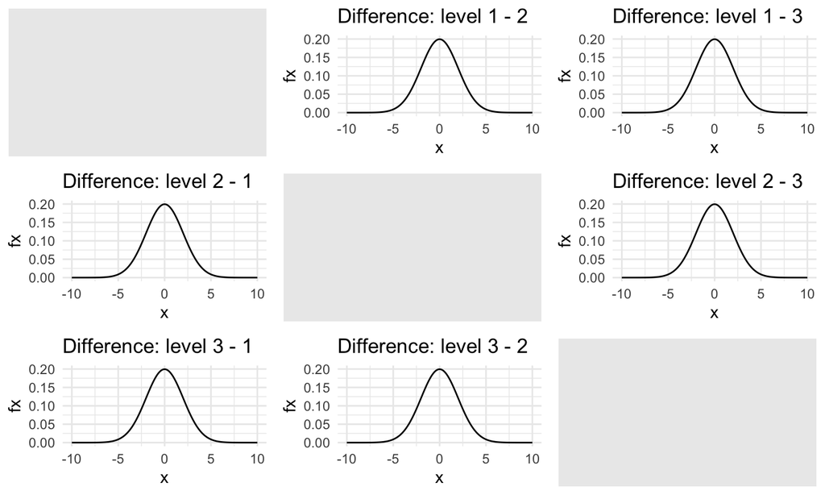

## Balance and types of sums of squares

- Different types of sums of squares only produce different results when the design is unbalanced.
- We will keep it simple: Always use type III sums of squares for every kind of ANOVA we cover in this unit.

## Question

The plot below shows the **variances of pairwise differences** among three within-subject conditions (A, B, C) in a repeated measures design.

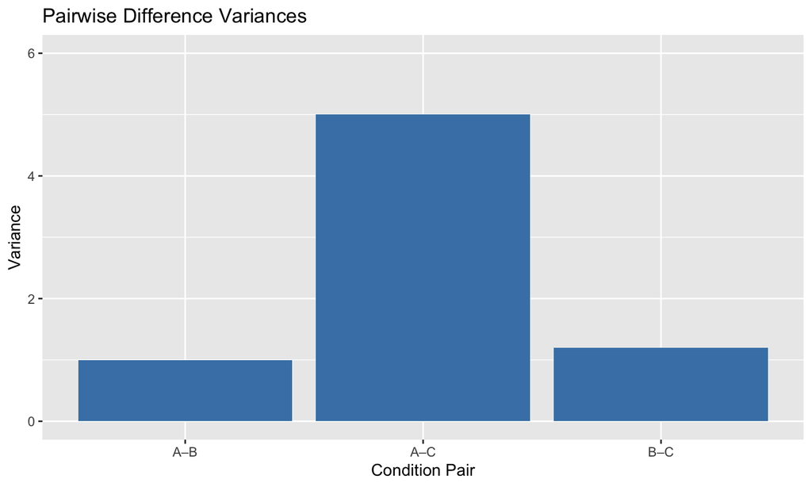

What assumption of repeated measures ANOVA does this violate?

This plot shows unequal variances of the pairwise differences among within-subject conditions, which violates the **sphericity assumption**. Sphericity requires these variances to be approximately equal. If violated, the F-test for the within-subject factor may be invalid unless corrected (e.g., using Greenhouse-Geisser).

## Question

Below are histograms of observed scores from three within-subject conditions in a repeated measures experiment.

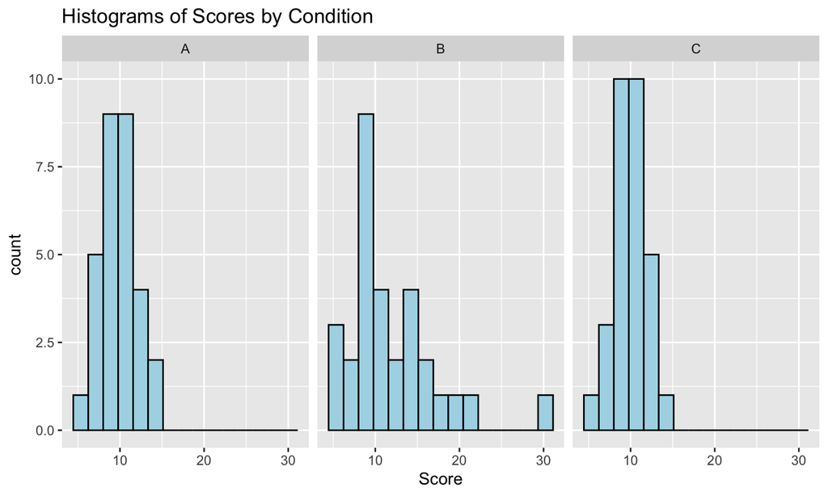

What assumption might be violated, and why is it relevant?

The histogram for Condition B shows strong skewness, suggesting a **violation of the normality assumption**. In repeated measures ANOVA, normality of residuals (equivalent to normality of scores within each condition) is assumed. This could affect validity, especially with small sample sizes.

## Question

The plot below shows the spread of scores across three conditions in a repeated measures design. It looks like one condition has a higher variance.

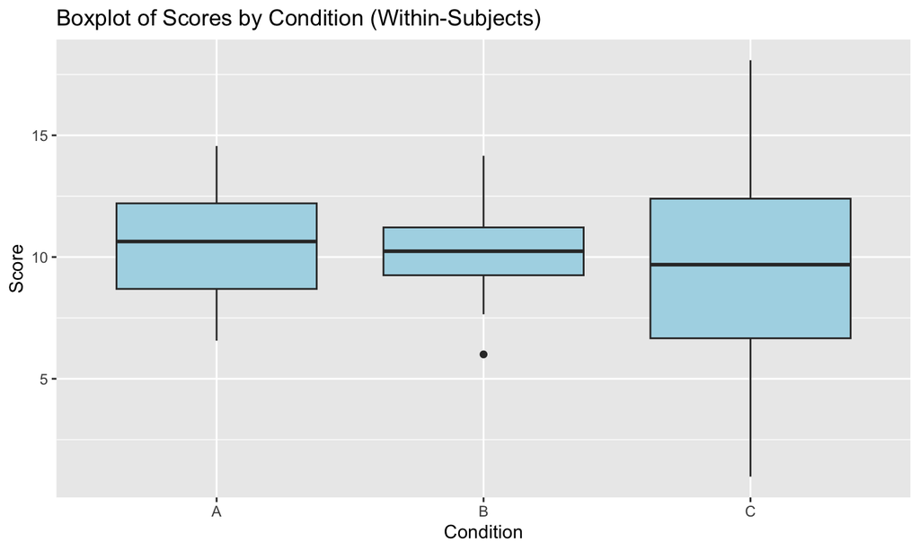

Does this violate a core assumption of repeated measures ANOVA?

Although the variances differ across conditions, this is **not** a violation of **homogeneity of variance**, which applies only to between-subjects designs. In repeated measures ANOVA, the key assumption is **sphericity**, not equal variances across conditions. The assumption we’d need to test is whether the **variances of pairwise differences** are equal.